# Mini-Project 1: Managing a Social Media Brand

MTH 365: Intro to Data Science

Due February 1, 2019

- Source: S. Moro, P. Rita and B. Vala. “Predicting social media performance metrics and evaluation of the impact on brand building: A data mining approach”. *Journal of Business Research*: 69 (9).

> Load the dataset into RStudio. How many social media posts are available?

The variable names in this dataset are complicated! To simplify things, we’ll rename the variables.

```r
colnames(dataset_Facebook) <- c('PageLikes', 'Type', 'Category', 'Month', 'Weekday', 'Hour', 'Paid', 'TotalReach', 'TotalImpressions', 'EngagedUsers', 'PostConsumers', 'PostConsumptions', 'ImpressionsByLikes', 'ReachByLikes', 'LikesEngaged', 'Comment', 'Like', 'Share', 'TotalInteractions')
names(dataset_Facebook)
```

[output not shown]

Some of these performance metrics are not intuitive. Facebook performance metrics generally fall into two categories: *visualizations* (posts loaded in users’ browsers) and *interactions* (clicks on posts).

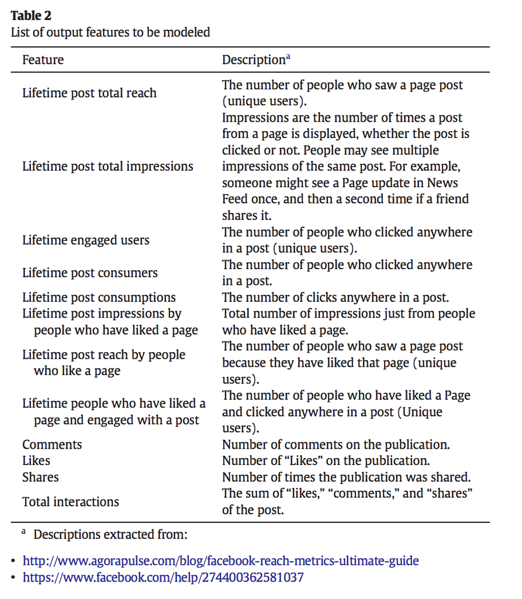

Use this data to answer the following research questions. For each question, you should produce *at least one data visualization*, with appropriate axis and legend labels. Each data visualization should be accompanied by a paragraph describing the insights to be gained.

> 1. What type of post engages this company’s Facebook followers the most?
> 2. When is the ideal time for this company to post a photo to Facebook? When is the ideal time for this company to update their status on Facebook?
> 3. On average, how many clicks does each user make per post?
> 4. On average, how many times does a user see each post?
> 5. How are shares and likes related? Does this depend on the type of post?
> 6. Do posts that reach a wider audience (more users) tend to have more interactions? Comments? Shares? Likes?
> 7. Do photos, links, or status updates reach a wider audience? What type of posts reach a *more engaged* audience?

Your submissions will be assessed on:

1. Quality of the data visualizations (5 pts. per question).
2. Quality of your written responses (3 pt. per question).
3. Code formatting: consistency, readability, etc. (2 pts. per question).

Total points possible: 70